# Exam1Part1_Starter(ANS)

## Table of Contents

- Identify and handle missing values
  - Identify missing values
  - Deal with missing values
  - Correct data format
- Data standardization
- Data normalization (centering/scaling)
- Binning
- Indicator variable

## Name: Preethi Nerella

## Banner ID: 001289365

### Import data

You can find the "Automobile Dataset" from the following link: https://archive.ics.uci.edu/ml/machine-learning-databases/autos/imports-85.data. You will be using this data for the first part of the exam. A slightly cleaned version of the data will be hosted in github for this part of the exam.

#### Import pandas

```python
import pandas as pd
import matplotlib.pylab as plt
import numpy as np
```

## Reading the dataset from the URL and adding the related headers

First, assign the URL of the data set to "filepath".

```python
filename="/content/imports-85.data.xlsx"
```

Then, create a Python list **headers** containing name of headers.

```python
headers = ["symboling","normalized-losses","make","fuel-type","aspiration", "num-of-doors","body-style",
         "drive-wheels","engine-location","wheel-base", "length","width","height","curb-weight","engine-type",
         "num-of-cylinders", "engine-size","fuel-system","bore","stroke","compression-ratio","horsepower",
         "peak-rpm","city-mpg","highway-mpg","price"]
```

Use the Pandas method **read_csv()** to load the data from the web address. Set the parameter "names" equal to the Python list "headers".

```python
df = pd.read_csv(filename, names = headers)
```

Use the method **head()** to display the first five rows of the dataframe.

```python
# To see what the data set looks like, we'll use the head() method.
df.head()
```

|  | symboling | normalized-losses | make | fuel-type | aspiration | num-of-doors | body-style | drive-wheels | engine-location | wheel-base | ... | engine-size | fuel-system | bore | stroke | compression-ratio | horsepower | peak-rpm | city-mpg | highway-mpg | price |
| --- | --- | --- | --- | --- | --- | --- | --- | --- | --- | --- | --- | --- | --- | --- | --- | --- | --- | --- | --- | --- | --- |
| 0 | 3 | ? | alfa-romero | gas | std | two | convertible | rwd | front | 88.6 | ... | 130 | mpfi | 3.47 | 2.68 | 9.0 | 111 | 5000 | 21 | 27 | 13495 |
| 1 | 3 | ? | alfa-romero | gas | std | two | convertible | rwd | front | 88.6 | ... | 130 | mpfi | 3.47 | 2.68 | 9.0 | 111 | 5000 | 21 | 27 | 16500 |
| 2 | 1 | ? | alfa-romero | gas | std | two | hatchback | rwd | front | 94.5 | ... | 152 | mpfi | 2.68 | 3.47 | 9.0 | 154 | 5000 | 19 | 26 | 16500 |
| 3 | 2 | 164 | audi | gas | std | four | sedan | fwd | front | 99.8 | ... | 109 | mpfi | 3.19 | 3.40 | 10.0 | 102 | 5500 | 24 | 30 | 13950 |
| 4 | 2 | 164 | audi | gas | std | four | sedan | 4wd | front | 99.4 | ... | 136 | mpfi | 3.19 | 3.40 | 8.0 | 115 | 5500 | 18 | 22 | 17450 |

5 rows × 26 columns

As you can see, several question marks appeared in the data frame; those missing values may hinder further analysis.

So, how do we identify all those missing values and deal with them?

**How to work with missing data?**

Steps for working with missing data:

1. Identify missing data
2. Deal with missing data
3. Correct data format

# Identify and handle missing values

### Identify missing values

#### Convert "?" to NaN

In the car data set, missing data comes with the question mark "?". We replace "?" with NaN (Not a Number), Python's default missing value marker for reasons of computational speed and convenience. Use the function:

```
.replace(A, B, inplace = True)
```

to replace A by B.

```python
import numpy as np

# replace "?" to NaN
df.replace("?", np.nan, inplace = True)
df.head(5)
```

|  | symboling | normalized-losses | make | fuel-type | aspiration | num-of-doors | body-style | drive-wheels | engine-location | wheel-base | ... | engine-size | fuel-system | bore | stroke | compression-ratio | horsepower | peak-rpm | city-mpg | highway-mpg | price |
| --- | --- | --- | --- | --- | --- | --- | --- | --- | --- | --- | --- | --- | --- | --- | --- | --- | --- | --- | --- | --- | --- |
| 0 | 3 | NaN | alfa-romero | gas | std | two | convertible | rwd | front | 88.6 | ... | 130 | mpfi | 3.47 | 2.68 | 9.0 | 111 | 5000 | 21 | 27 | 13495 |
| 1 | 3 | NaN | alfa-romero | gas | std | two | convertible | rwd | front | 88.6 | ... | 130 | mpfi | 3.47 | 2.68 | 9.0 | 111 | 5000 | 21 | 27 | 16500 |
| 2 | 1 | NaN | alfa-romero | gas | std | two | hatchback | rwd | front | 94.5 | ... | 152 | mpfi | 2.68 | 3.47 | 9.0 | 154 | 5000 | 19 | 26 | 16500 |
| 3 | 2 | 164 | audi | gas | std | four | sedan | fwd | front | 99.8 | ... | 109 | mpfi | 3.19 | 3.40 | 10.0 | 102 | 5500 | 24 | 30 | 13950 |
| 4 | 2 | 164 | audi | gas | std | four | sedan | 4wd | front | 99.4 | ... | 136 | mpfi | 3.19 | 3.40 | 8.0 | 115 | 5500 | 18 | 22 | 17450 |

5 rows × 26 columns

#### Evaluating for Missing Data

The missing values are converted by default. Use the following functions to identify these missing values. You can use two methods to detect missing data:

1. **.isnull()**
2. **.notnull()**

The output is a boolean value indicating whether the value that is passed into the argument is in fact missing data.

```python
missing_data = df.isnull()
missing_data.head(5)
```

|  | symboling | normalized-losses | make | fuel-type | aspiration | num-of-doors | body-style | drive-wheels | engine-location | wheel-base | ... | engine-size | fuel-system | bore | stroke | compression-ratio | horsepower | peak-rpm | city-mpg | highway-mpg | price |
| --- | --- | --- | --- | --- | --- | --- | --- | --- | --- | --- | --- | --- | --- | --- | --- | --- | --- | --- | --- | --- | --- |
| 0 | False | True | False | False | False | False | False | False | False | False | ... | False | False | False | False | False | False | False | False | False | False |
| 1 | False | True | False | False | False | False | False | False | False | False | ... | False | False | False | False | False | False | False | False | False | False |
| 2 | False | True | False | False | False | False | False | False | False | False | ... | False | False | False | False | False | False | False | False | False | False |
| 3 | False | False | False | False | False | False | False | False | False | False | ... | False | False | False | False | False | False | False | False | False | False |
| 4 | False | False | False | False | False | False | False | False | False | False | ... | False | False | False | False | False | False | False | False | False | False |

5 rows × 26 columns

"True" means the value is a missing value while "False" means the value is not a missing value.

#### Count missing values in each column

Using a for loop in Python, you can quickly figure out the number of missing values in each column. As mentioned above, "True" represents a missing value and "False" means the value is present in the data set. In the body of the for loop the method ".value_counts()" counts the number of "True" values.

```python
for column in missing_data.columns.values.tolist():
    print(column)
    print (missing_data[column].value_counts())
    print("")
```

```
symboling
symboling
False    205
Name: count, dtype: int64

normalized-losses
normalized-losses
False    164
True      41
Name: count, dtype: int64

make
make
False    205
Name: count, dtype: int64

fuel-type
fuel-type
False    205
Name: count, dtype: int64

aspiration
aspiration
False    205
Name: count, dtype: int64

num-of-doors
num-of-doors
False    203
True       2
Name: count, dtype: int64

body-style
body-style
False    205
Name: count, dtype: int64

drive-wheels
drive-wheels
False    205
```

[output cut: 81 more lines]

```
city-mpg
city-mpg
False    205
Name: count, dtype: int64

highway-mpg
highway-mpg
False    205
Name: count, dtype: int64

price
price
False    201
True       4
Name: count, dtype: int64
```

Based on the summary above, each column has 205 rows of data and seven of the columns containing missing data:

1. "normalized-losses": 41 missing data
2. "num-of-doors": 2 missing data
3. "bore": 4 missing data
4. "stroke" : 4 missing data
5. "horsepower": 2 missing data
6. "peak-rpm": 2 missing data
7. "price": 4 missing data

### Deal with missing data

**How should you deal with missing data?**

1. Drop data  
   a. Drop the whole row  
   b. Drop the whole column
2. Replace data  
   a. Replace it by mean  
   b. Replace it by frequency  
   c. Replace it based on other functions

You should only drop whole columns if most entries in the column are empty. In the data set, none of the columns are empty enough to drop entirely. You have some freedom in choosing which method to replace data; however, some methods may seem more reasonable than others. Apply each method to different columns:

**Replace by mean:**

- "normalized-losses": 41 missing data, replace them with mean
- "stroke": 4 missing data, replace them with mean
- "bore": 4 missing data, replace them with mean
- "horsepower": 2 missing data, replace them with mean
- "peak-rpm": 2 missing data, replace them with mean

**Replace by frequency:**

- "num-of-doors": 2 missing data, replace them with "four".
  - Reason: 84% sedans are four doors. Since four doors is most frequent, it is most likely to occur

**Drop the whole row:**

- "price": 4 missing data, simply delete the whole row
  - Reason: You want to predict price. You cannot use any data entry without price data for prediction; therefore any row now without price data is not useful to you.

#### Calculate the mean value for the "normalized-losses" column

```python
avg_norm_loss = df["normalized-losses"].astype("float").mean(axis=0)
print("Average of normalized-losses:", avg_norm_loss)
```

```
Average of normalized-losses: 122.0
```

#### Replace "NaN" with mean value in "normalized-losses" column

```python
# Replace NaN in 'normalized-losses' with avg_norm_loss
df["normalized-losses"] = df["normalized-losses"].replace(np.nan, avg_norm_loss)

# Confirm no NaN values in 'normalized-losses'
print(f"Missing values in normalized-losses: {df['normalized-losses'].isnull().sum()}")
```

```
Missing values in normalized-losses: 0
```

#### Calculate the mean value for the "bore" column

```python
avg_bore=df['bore'].astype('float').mean(axis=0)
print("Average of bore:", avg_bore)
```

```
Average of bore: 3.3297512437810943
```

#### Replace "NaN" with the mean value in the "bore" column

```python
# Replace NaN in 'bore' with avg_bore
df["bore"] = df["bore"].replace(np.nan, avg_bore)

# Confirm no NaN values in 'bore'
print(f"Missing values in bore: {df['bore'].isnull().sum()}")
```

```
Missing values in bore: 0
```

# Question #1:

**Based on the example above, replace NaN in "stroke" column with the mean value.**

```python
# Write your code below and press Shift+Enter to execute
# Convert 'stroke' to numeric just in case
df["stroke"] = pd.to_numeric(df["stroke"], errors="coerce")

# Calculate mean of stroke
mean_stroke = df["stroke"].mean()

# Replace NaN with mean
df["stroke"] = df["stroke"].fillna(mean_stroke)

# Confirm no NaN values in 'stroke'
print(f"Missing values in stroke: {df['stroke'].isnull().sum()}")
```

```
Missing values in stroke: 0
```

#### Calculate the mean value for the "horsepower" column

```python
avg_horsepower = df['horsepower'].astype('float').mean(axis=0)
print("Average horsepower:", avg_horsepower)
```

```
Average horsepower: 104.25615763546799
```

#### Replace "NaN" with the mean value in the "horsepower" column

```python
# Replace NaN in 'horsepower' with avg_horsepower
df['horsepower'] = df['horsepower'].replace(np.nan, avg_horsepower)

# Confirm no NaN values in 'horsepower'
print(f"Missing values in horsepower: {df['horsepower'].isnull().sum()}")
```

```
Missing values in horsepower: 0
```

#### Calculate the mean value for "peak-rpm" column

```python
avg_peakrpm=df['peak-rpm'].astype('float').mean(axis=0)
print("Average peak rpm:", avg_peakrpm)
```

```
Average peak rpm: 5125.369458128079
```

#### Replace "NaN" with the mean value in the "peak-rpm" column

```python
# Replace NaN in 'peak-rpm' with avg_peakrpm
df['peak-rpm'] = df['peak-rpm'].replace(np.nan, avg_peakrpm)

# Confirm no NaN values in 'peak-rpm'
print(f"Missing values in peak-rpm: {df['peak-rpm'].isnull().sum()}")
```

```
Missing values in peak-rpm: 0
```

To see which values are present in a particular column, we can use the ".value_counts()" method:

```python
df['num-of-doors'].value_counts()
```

| num-of-doors | count |
| --- | --- |
| four | 114 |
| two | 89 |

**dtype:** int64

You can see that four doors is the most common type. We can also use the ".idxmax()" method to calculate the most common type automatically:

```python
df['num-of-doors'].value_counts().idxmax()
```

```
'four'
```

The replacement procedure is very similar to what you have seen previously:

```python
# Replace NaN in 'num-of-doors' with the most frequent value 'four'
df["num-of-doors"] = df["num-of-doors"].replace(np.nan, "four")

# Confirm no NaN values in 'num-of-doors'
print(f"Missing values in num-of-doors: {df['num-of-doors'].isnull().sum()}")
```

```
Missing values in num-of-doors: 0
```

Finally, drop all rows that do not have price data:

```python
# simply drop whole row with NaN in "price" column
df.dropna(subset=["price"], axis=0, inplace=True)

# reset index, because we droped two rows
df.reset_index(drop=True, inplace=True)
```

```python
df.head()
```

|  | symboling | normalized-losses | make | fuel-type | aspiration | num-of-doors | body-style | drive-wheels | engine-location | wheel-base | ... | engine-size | fuel-system | bore | stroke | compression-ratio | horsepower | peak-rpm | city-mpg | highway-mpg | price |
| --- | --- | --- | --- | --- | --- | --- | --- | --- | --- | --- | --- | --- | --- | --- | --- | --- | --- | --- | --- | --- | --- |
| 0 | 3 | 122.0 | alfa-romero | gas | std | two | convertible | rwd | front | 88.6 | ... | 130 | mpfi | 3.47 | 2.68 | 9.0 | 111 | 5000 | 21 | 27 | 13495 |
| 1 | 3 | 122.0 | alfa-romero | gas | std | two | convertible | rwd | front | 88.6 | ... | 130 | mpfi | 3.47 | 2.68 | 9.0 | 111 | 5000 | 21 | 27 | 16500 |
| 2 | 1 | 122.0 | alfa-romero | gas | std | two | hatchback | rwd | front | 94.5 | ... | 152 | mpfi | 2.68 | 3.47 | 9.0 | 154 | 5000 | 19 | 26 | 16500 |
| 3 | 2 | 164 | audi | gas | std | four | sedan | fwd | front | 99.8 | ... | 109 | mpfi | 3.19 | 3.40 | 10.0 | 102 | 5500 | 24 | 30 | 13950 |
| 4 | 2 | 164 | audi | gas | std | four | sedan | 4wd | front | 99.4 | ... | 136 | mpfi | 3.19 | 3.40 | 8.0 | 115 | 5500 | 18 | 22 | 17450 |

5 rows × 26 columns

**Good!** Now, you have a data set with no missing values.

### Correct data format

**We are almost there!**

The last step in data cleaning is checking and making sure that all data is in the correct format (int, float, text or other).

In Pandas, you use:

**.dtype()** to check the data type

**.astype()** to change the data type

#### Let's list the data types for each column

```python
df.dtypes
```

|  | 0 |
| --- | --- |
| symboling | int64 |
| normalized-losses | object |
| make | object |
| fuel-type | object |
| aspiration | object |
| num-of-doors | object |
| body-style | object |
| drive-wheels | object |
| engine-location | object |
| wheel-base | float64 |
| length | float64 |
| width | float64 |
| height | float64 |
| curb-weight | int64 |
| engine-type | object |
| num-of-cylinders | object |
| engine-size | int64 |
| fuel-system | object |
| bore | object |
| stroke | float64 |
| compression-ratio | float64 |
| horsepower | object |
| peak-rpm | object |
| city-mpg | int64 |
| highway-mpg | int64 |
| price | object |

**dtype:** object

#### Convert data types to proper format

```python
df[["bore", "stroke"]] = df[["bore", "stroke"]].astype("float")
df[["normalized-losses"]] = df[["normalized-losses"]].astype("int")
df[["price"]] = df[["price"]].astype("float")
df[["peak-rpm"]] = df[["peak-rpm"]].astype("float")
```

#### Let us list the columns after the conversion

```python
df.dtypes
```

|  | 0 |
| --- | --- |
| symboling | int64 |
| normalized-losses | int64 |
| make | object |
| fuel-type | object |
| aspiration | object |
| num-of-doors | object |
| body-style | object |
| drive-wheels | object |
| engine-location | object |
| wheel-base | float64 |
| length | float64 |
| width | float64 |
| height | float64 |
| curb-weight | int64 |
| engine-type | object |
| num-of-cylinders | object |
| engine-size | int64 |
| fuel-system | object |
| bore | float64 |
| stroke | float64 |
| compression-ratio | float64 |
| horsepower | object |
| peak-rpm | float64 |
| city-mpg | int64 |
| highway-mpg | int64 |
| price | float64 |

**dtype:** object

**Wonderful!**

Now you finally obtained the cleansed data set with no missing values and with all data in its proper format.

## Data Standardization

You usually collect data from different agencies in different formats. (Data standardization is also a term for a particular type of data normalization where you subtract the mean and divide by the standard deviation.)

**What is standardization?**

Standardization is the process of transforming data into a common format, allowing the researcher to make the meaningful comparison.

**Example**

Transform mpg to L/100km:

In your data set, the fuel consumption columns "city-mpg" and "highway-mpg" are represented by mpg (miles per gallon) unit. Assume you are developing an application in a country that accepts the fuel consumption with L/100km standard.

You will need to apply **data transformation** to transform mpg into L/100km.

Use this formula for unit conversion:

L/100km = 235 / mpg

You can do many mathematical operations directly using Pandas.

```python
df.head()
```

|  | symboling | normalized-losses | make | fuel-type | aspiration | num-of-doors | body-style | drive-wheels | engine-location | wheel-base | ... | engine-size | fuel-system | bore | stroke | compression-ratio | horsepower | peak-rpm | city-mpg | highway-mpg | price |
| --- | --- | --- | --- | --- | --- | --- | --- | --- | --- | --- | --- | --- | --- | --- | --- | --- | --- | --- | --- | --- | --- |
| 0 | 3 | 122 | alfa-romero | gas | std | two | convertible | rwd | front | 88.6 | ... | 130 | mpfi | 3.47 | 2.68 | 9.0 | 111 | 5000.0 | 21 | 27 | 13495.0 |
| 1 | 3 | 122 | alfa-romero | gas | std | two | convertible | rwd | front | 88.6 | ... | 130 | mpfi | 3.47 | 2.68 | 9.0 | 111 | 5000.0 | 21 | 27 | 16500.0 |
| 2 | 1 | 122 | alfa-romero | gas | std | two | hatchback | rwd | front | 94.5 | ... | 152 | mpfi | 2.68 | 3.47 | 9.0 | 154 | 5000.0 | 19 | 26 | 16500.0 |
| 3 | 2 | 164 | audi | gas | std | four | sedan | fwd | front | 99.8 | ... | 109 | mpfi | 3.19 | 3.40 | 10.0 | 102 | 5500.0 | 24 | 30 | 13950.0 |
| 4 | 2 | 164 | audi | gas | std | four | sedan | 4wd | front | 99.4 | ... | 136 | mpfi | 3.19 | 3.40 | 8.0 | 115 | 5500.0 | 18 | 22 | 17450.0 |

5 rows × 26 columns

```python
# Convert mpg to L/100km by mathematical operation (235 divided by mpg)
df['city-L/100km'] = 235/df["city-mpg"]

# check your transformed data
df.head()
```

|  | symboling | normalized-losses | make | fuel-type | aspiration | num-of-doors | body-style | drive-wheels | engine-location | wheel-base | ... | fuel-system | bore | stroke | compression-ratio | horsepower | peak-rpm | city-mpg | highway-mpg | price | city-L/100km |
| --- | --- | --- | --- | --- | --- | --- | --- | --- | --- | --- | --- | --- | --- | --- | --- | --- | --- | --- | --- | --- | --- |
| 0 | 3 | 122 | alfa-romero | gas | std | two | convertible | rwd | front | 88.6 | ... | mpfi | 3.47 | 2.68 | 9.0 | 111 | 5000.0 | 21 | 27 | 13495.0 | 11.190476 |
| 1 | 3 | 122 | alfa-romero | gas | std | two | convertible | rwd | front | 88.6 | ... | mpfi | 3.47 | 2.68 | 9.0 | 111 | 5000.0 | 21 | 27 | 16500.0 | 11.190476 |
| 2 | 1 | 122 | alfa-romero | gas | std | two | hatchback | rwd | front | 94.5 | ... | mpfi | 2.68 | 3.47 | 9.0 | 154 | 5000.0 | 19 | 26 | 16500.0 | 12.368421 |
| 3 | 2 | 164 | audi | gas | std | four | sedan | fwd | front | 99.8 | ... | mpfi | 3.19 | 3.40 | 10.0 | 102 | 5500.0 | 24 | 30 | 13950.0 | 9.791667 |
| 4 | 2 | 164 | audi | gas | std | four | sedan | 4wd | front | 99.4 | ... | mpfi | 3.19 | 3.40 | 8.0 | 115 | 5500.0 | 18 | 22 | 17450.0 | 13.055556 |

5 rows × 27 columns

# Question #2:

**According to the example above, transform mpg to L/100km in the column of "highway-mpg" and change the name of column to "highway-L/100km".**

```python
# Write your code below and press Shift+Enter to execute
# Convert highway-mpg to numeric
df["highway-mpg"] = pd.to_numeric(df["highway-mpg"], errors="coerce")

# Apply the conversion formula
df["highway-L/100km"] = 235 / df["highway-mpg"]

# Drop the old column if needed (optional)
# df.drop("highway-mpg", axis=1, inplace=True)

# Display result
df[["highway-mpg", "highway-L/100km"]].head()
```

|  | highway-mpg | highway-L/100km |
| --- | --- | --- |
| 0 | 27 | 8.703704 |
| 1 | 27 | 8.703704 |
| 2 | 26 | 9.038462 |
| 3 | 30 | 7.833333 |
| 4 | 22 | 10.681818 |

## Data Normalization

**Why normalization?**

Normalization is the process of transforming values of several variables into a similar range. Typical normalizations include

1. scaling the variable so the variable average is 0
2. scaling the variable so the variance is 1
3. scaling the variable so the variable values range from 0 to 1

**Example**

To demonstrate normalization, say you want to scale the columns "length", "width" and "height".

**Target:** normalize those variables so their value ranges from 0 to 1

**Approach:** replace the original value by (original value)/(maximum value)

```python
# replace (original value) by (original value)/(maximum value)
df['length'] = df['length']/df['length'].max()
df['width'] = df['width']/df['width'].max()
```

# Question #3:

**According to the example above, normalize the column "height".**

```python
# Write your code below and press Shift+Enter to execute
# Convert to numeric just in case
df["height"] = pd.to_numeric(df["height"], errors="coerce")

# Apply Min-Max normalization
df["height_normalized"] = (df["height"] - df["height"].min()) / (df["height"].max() - df["height"].min())

# Display result
df[["height", "height_normalized"]].head()
```

|  | height | height_normalized |
| --- | --- | --- |
| 0 | 48.8 | 0.083333 |
| 1 | 48.8 | 0.083333 |
| 2 | 52.4 | 0.383333 |
| 3 | 54.3 | 0.541667 |
| 4 | 54.3 | 0.541667 |

Here you've normalized "length", "width" and "height" to fall in the range of [0,1].

## Binning

**Why binning?**

Binning is a process of transforming continuous numerical variables into discrete categorical 'bins' for grouped analysis.

**Example:**

Use the Pandas method 'cut' to segment the 'horsepower' column into 3 bins.

### Example of Binning Data In Pandas

Convert data to correct format:

```python
df["horsepower"]=df["horsepower"].astype(int, copy=True)
```

Plot the histogram of horsepower to see the distribution of horsepower.

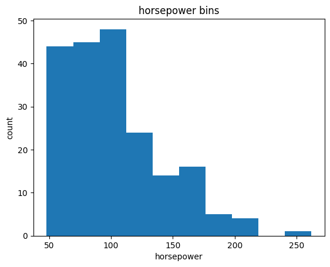

```python
%matplotlib inline
import matplotlib as plt
from matplotlib import pyplot
plt.pyplot.hist(df["horsepower"])

# set x/y labels and plot title
plt.pyplot.xlabel("horsepower")
plt.pyplot.ylabel("count")
plt.pyplot.title("horsepower bins")
```

Find 3 bins of equal size bandwidth by using Numpy's `linspace(start_value, end_value, numbers_generated)` function.

Since you want to include the minimum value of horsepower, set start_value = min(df["horsepower"]).

Since you want to include the maximum value of horsepower, set end_value = max(df["horsepower"]).

Since you are building 3 bins of equal length, you need 4 dividers, so numbers_generated = 4.

Build a bin array with a minimum value to a maximum value by using the bandwidth calculated above. The values will determine when one bin ends and another begins.

```python
bins = np.linspace(min(df["horsepower"]), max(df["horsepower"]), 4)
bins
```

```
array([ 48.        , 119.33333333, 190.66666667, 262.        ])
```

Set group names:

```python
group_names = ['Low', 'Medium', 'High']
```

Apply the function "cut" to determine what each value of `df['horsepower']` belongs to.

```python
df['horsepower-binned'] = pd.cut(df['horsepower'], bins, labels=group_names, include_lowest=True )
df[['horsepower','horsepower-binned']].head(20)
```

|  | horsepower | horsepower-binned |
| --- | --- | --- |
| 0 | 111 | Low |
| 1 | 111 | Low |
| 2 | 154 | Medium |
| 3 | 102 | Low |
| 4 | 115 | Low |
| 5 | 110 | Low |
| 6 | 110 | Low |
| 7 | 110 | Low |
| 8 | 140 | Medium |
| 9 | 101 | Low |
| 10 | 101 | Low |
| 11 | 121 | Medium |
| 12 | 121 | Medium |
| 13 | 121 | Medium |
| 14 | 182 | Medium |
| 15 | 182 | Medium |
| 16 | 182 | Medium |
| 17 | 48 | Low |
| 18 | 70 | Low |
| 19 | 70 | Low |

See the number of vehicles in each bin:

```python
df["horsepower-binned"].value_counts()
```

| horsepower-binned | count |
| --- | --- |
| Low | 153 |
| Medium | 43 |
| High | 5 |

**dtype:** int64

Plot the distribution of each bin:

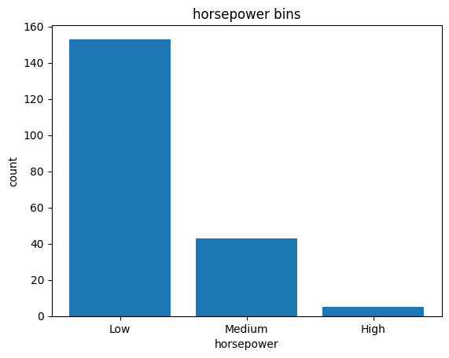

```python
%matplotlib inline
import matplotlib as plt
from matplotlib import pyplot
pyplot.bar(group_names, df["horsepower-binned"].value_counts())

# set x/y labels and plot title
plt.pyplot.xlabel("horsepower")
plt.pyplot.ylabel("count")
plt.pyplot.title("horsepower bins")
```

Look at the data frame above carefully. You will find that the last column provides the bins for "horsepower" based on 3 categories ("Low", "Medium" and "High").

You successfully narrowed down the intervals from 59 to 3!

### Bins Visualization

Normally, you use a histogram to visualize the distribution of bins we created above.

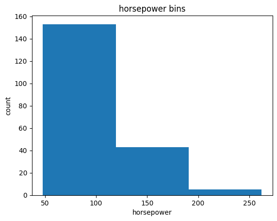

```python
%matplotlib inline
import matplotlib as plt
from matplotlib import pyplot


# draw historgram of attribute "horsepower" with bins = 3
plt.pyplot.hist(df["horsepower"], bins = 3)

# set x/y labels and plot title
plt.pyplot.xlabel("horsepower")
plt.pyplot.ylabel("count")
plt.pyplot.title("horsepower bins")
```

The plot above shows the binning result for the attribute "horsepower".

## Indicator Variable

**What is an indicator variable?**

An indicator variable (or dummy variable) is a numerical variable used to label categories. They are called 'dummies' because the numbers themselves don't have inherent meaning.

**Why use indicator variables?**

You use indicator variables so you can use categorical variables for regression analysis in the later modules.

**Example**

The column "fuel-type" has two unique values: "gas" or "diesel". Regression doesn't understand words, only numbers. To use this attribute in regression analysis, you can convert "fuel-type" to indicator variables.

Use the Panda method 'get_dummies' to assign numerical values to different categories of fuel type.

```python
df.columns
```

```
Index(['symboling', 'normalized-losses', 'make', 'fuel-type', 'aspiration',
       'num-of-doors', 'body-style', 'drive-wheels', 'engine-location',
       'wheel-base', 'length', 'width', 'height', 'curb-weight', 'engine-type',
       'num-of-cylinders', 'engine-size', 'fuel-system', 'bore', 'stroke',
       'compression-ratio', 'horsepower', 'peak-rpm', 'city-mpg',
       'highway-mpg', 'price', 'city-L/100km', 'highway-L/100km',
       'height_normalized', 'horsepower-binned'],
      dtype='object')
```

Get the indicator variables and assign it to data frame "dummy_variable_1":

```python
dummy_variable_1 = pd.get_dummies(df["fuel-type"])
dummy_variable_1.head()
```

|  | diesel | gas |
| --- | --- | --- |
| 0 | False | True |
| 1 | False | True |
| 2 | False | True |
| 3 | False | True |
| 4 | False | True |

Change the column names for clarity:

```python
dummy_variable_1.rename(columns={'gas':'fuel-type-gas', 'diesel':'fuel-type-diesel'}, inplace=True)
dummy_variable_1.head()
```

|  | fuel-type-diesel | fuel-type-gas |
| --- | --- | --- |
| 0 | False | True |
| 1 | False | True |
| 2 | False | True |
| 3 | False | True |
| 4 | False | True |

```python
# merge data frame "df" and "dummy_variable_1"
df = pd.concat([df, dummy_variable_1], axis=1)

# drop original column "fuel-type" from "df"
df.drop("fuel-type", axis = 1, inplace=True)
```

```python
df.head()
```

|  | symboling | normalized-losses | make | aspiration | num-of-doors | body-style | drive-wheels | engine-location | wheel-base | length | ... | peak-rpm | city-mpg | highway-mpg | price | city-L/100km | highway-L/100km | height_normalized | horsepower-binned | fuel-type-diesel | fuel-type-gas |
| --- | --- | --- | --- | --- | --- | --- | --- | --- | --- | --- | --- | --- | --- | --- | --- | --- | --- | --- | --- | --- | --- |
| 0 | 3 | 122 | alfa-romero | std | two | convertible | rwd | front | 88.6 | 0.811148 | ... | 5000.0 | 21 | 27 | 13495.0 | 11.190476 | 8.703704 | 0.083333 | Low | False | True |
| 1 | 3 | 122 | alfa-romero | std | two | convertible | rwd | front | 88.6 | 0.811148 | ... | 5000.0 | 21 | 27 | 16500.0 | 11.190476 | 8.703704 | 0.083333 | Low | False | True |
| 2 | 1 | 122 | alfa-romero | std | two | hatchback | rwd | front | 94.5 | 0.822681 | ... | 5000.0 | 19 | 26 | 16500.0 | 12.368421 | 9.038462 | 0.383333 | Medium | False | True |
| 3 | 2 | 164 | audi | std | four | sedan | fwd | front | 99.8 | 0.848630 | ... | 5500.0 | 24 | 30 | 13950.0 | 9.791667 | 7.833333 | 0.541667 | Low | False | True |
| 4 | 2 | 164 | audi | std | four | sedan | 4wd | front | 99.4 | 0.848630 | ... | 5500.0 | 18 | 22 | 17450.0 | 13.055556 | 10.681818 | 0.541667 | Low | False | True |

5 rows × 31 columns

# Question #4:

**Similar to before, create an indicator variable for the column "aspiration"**

```python
# Write your code below and press Shift+Enter to execute
# Create dummy variable for 'aspiration'
aspiration_dummies = pd.get_dummies(df["aspiration"], prefix="aspiration", drop_first=True)

# Concatenate with original DataFrame
df = pd.concat([df, aspiration_dummies], axis=1)

# Display the new dummy column
df[["aspiration", *aspiration_dummies.columns]].head()
```

|  | aspiration | aspiration_turbo |
| --- | --- | --- |
| 0 | std | False |
| 1 | std | False |
| 2 | std | False |
| 3 | std | False |
| 4 | std | False |

# Question #5:

**Merge the new dataframe to the original (Dataframe after Question 4) dataframe, then drop the column 'aspiration'.**

```python
# Write your code below and press Shift+Enter to execute
# Drop the original 'aspiration' column
df.drop("aspiration", axis=1, inplace=True)

# Check result
df.head()
```

|  | symboling | normalized-losses | make | num-of-doors | body-style | drive-wheels | engine-location | wheel-base | length | width | ... | city-mpg | highway-mpg | price | city-L/100km | highway-L/100km | height_normalized | horsepower-binned | fuel-type-diesel | fuel-type-gas | aspiration_turbo |
| --- | --- | --- | --- | --- | --- | --- | --- | --- | --- | --- | --- | --- | --- | --- | --- | --- | --- | --- | --- | --- | --- |
| 0 | 3 | 122 | alfa-romero | two | convertible | rwd | front | 88.6 | 0.811148 | 0.890278 | ... | 21 | 27 | 13495.0 | 11.190476 | 8.703704 | 0.083333 | Low | False | True | False |
| 1 | 3 | 122 | alfa-romero | two | convertible | rwd | front | 88.6 | 0.811148 | 0.890278 | ... | 21 | 27 | 16500.0 | 11.190476 | 8.703704 | 0.083333 | Low | False | True | False |
| 2 | 1 | 122 | alfa-romero | two | hatchback | rwd | front | 94.5 | 0.822681 | 0.909722 | ... | 19 | 26 | 16500.0 | 12.368421 | 9.038462 | 0.383333 | Medium | False | True | False |
| 3 | 2 | 164 | audi | four | sedan | fwd | front | 99.8 | 0.848630 | 0.919444 | ... | 24 | 30 | 13950.0 | 9.791667 | 7.833333 | 0.541667 | Low | False | True | False |
| 4 | 2 | 164 | audi | four | sedan | 4wd | front | 99.4 | 0.848630 | 0.922222 | ... | 18 | 22 | 17450.0 | 13.055556 | 10.681818 | 0.541667 | Low | False | True | False |

5 rows × 31 columns

Save the new csv:

```python
df.to_csv('clean_df.csv')
```

# Question #6:

**How many Rows and Columns do you have in the final Dataframe?**

```python
# Write your code below and press Shift+Enter to execute
# Print the shape of the final DataFrame
print("Final DataFrame shape (rows, columns):", df.shape)
```

```
Final DataFrame shape (rows, columns): (201, 31)
```